# Data Journalism Seminar

Trevor Nishida

MATH 271 SP2022

- Story: https://fivethirtyeight.com/features/americas-favorite-star-wars-movies-and-least-favorite-characters/
- Data: https://github.com/fivethirtyeight/data/tree/master/star-wars-survey
- Rmd: Use the “Code” menu at the top right of the page to download the source file for this report.

```r
link = "https://raw.githubusercontent.com/fivethirtyeight/data/master/star-wars-survey/StarWars.csv"

starwarscol = c("id", "seen", "fan", "ep1", "ep2", "ep3", "ep4", "ep5", "ep6", "fave1", "fave2", "fave3", "fave4", "fave5", "fave6", "han", "luke", "leia", "anakin", "obiwan", "palpatine", "vader", "lando", "boba", "c3po", "r2d2", "jarjar", "padme", "yoda", "shot", "expand", "expandfan", "startrek", "gender", "age", "income", "education", "region")

#macOS or Linux
#data = read.csv(link, header=T, na.strings=c("","NA"), fileEncoding = 'Latin1') %>%
# set_colnames(starwarscol) %>%
# slice(3:n()) %>%
# mutate_at(4:9, ~recode(., .default = 1)) %>%
# mutate(across(4:9, ~replace_na(., 0)))
ogdata = read.csv(link)

#Windows
data = read.csv(link, header=T, na.strings=c("","NA")) %>%
  set_colnames(starwarscol) %>%
  slice(3:n()) %>%
  mutate_at(4:9, ~recode(., .default = 1)) %>%
  mutate(across(4:9, ~replace_na(., 0)))
```

## **America’s Favorite ‘*Star Wars*’ Movies** **(And Least Favorite Characters)**

[figure not shown]

Yoda’s costume from the “Star Wars” series is displayed during an exhibition at the Cite du Cinema in Saint-Denis, France  
CHESNOT / Getty Images

### Introduction

Each respondent was asked whether they watched any “Star Wars” films, whether they considered themselves to be a “Star Wars” fan, to check boxes regarding which movies they have watched (if any), and if they did watch all 6 movies to rank them from best to worst. Respondents then had to rate various main and supporting characters from the franchise on a scale from Favorable to Unfavorable. Questions about their age, gender, region, and income were also asked. The survey finished off with a question referencing a scene in the film *Episode IV - A New Hope* wherein supporting character Han Solo shoots an alien accomplice. In the article, they use this data to conclude that among “Star Wars” fans there is a gender discrepancy. The also display the various percentage of respondents who viewed each film as well as the popularity. Then they show the various character ratings among each rank on the scale and finish off the article with the question referencing the Han Solo scene.

### Visualization Recreations

The article contains 5 total visualizations. The visualization on the left displays the probability that any fan has seen a given “Star Wars” film. The one on the right displays the percentage of the fan base which rates a given “Star Wars” film as the best overall. I also noticed a mismatch in both number of respondents who’ve seen any film and the number of respondents who’ve seen all six between my analysis and the original one done by FiveThirtyEight.

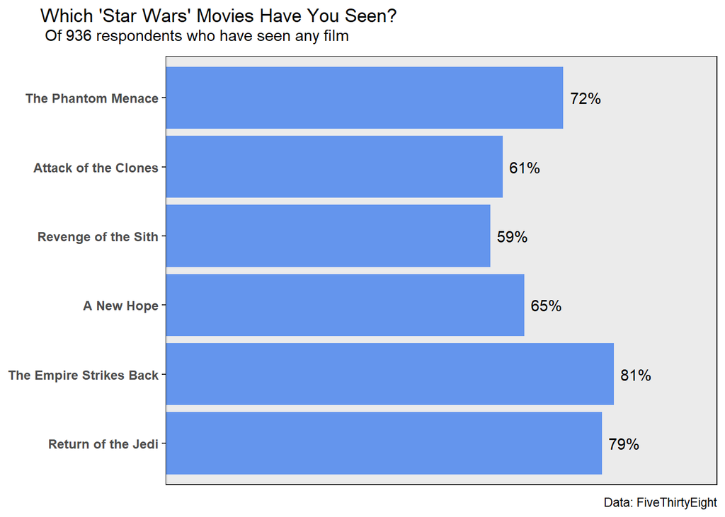

```r
firstViz = data %>%
  filter(seen == "Yes") %>%
  select(1:9) %>%
  summarise(across(4:9, ~mean(.))) %>%
  pivot_longer(everything(), names_to = "episode", values_to = "perc") %>%
  mutate(episode = recode(episode, "ep1" = "The Phantom Menace",
                          "ep2" = "Attack of the Clones",
                          "ep3" = "Revenge of the Sith",
                          "ep4" = "A New Hope",
                          "ep5" = "The Empire Strikes Back",
                          "ep6" = "Return of the Jedi"))

movie_order = c("The Phantom Menace", "Attack of the Clones", "Revenge of the Sith", "A New Hope", "The Empire Strikes Back", "Return of the Jedi")

EPperc = c(0.72, 0.61, 0.59, 0.65, 0.81, 0.79)


ggplot(firstViz) +
  aes(x = factor(episode, level = movie_order), y = perc) +
  geom_bar(stat = "identity", fill = "cornflowerblue") +
  coord_flip(ylim = c(0.0475, 0.95)) +
  scale_x_discrete(limits = rev) +
  scale_y_continuous(labels = scales::percent, limits = c(0,1)) +
  labs(title = "Which 'Star Wars' Movies Have You Seen?",
       subtitle = "Of 936 respondents who have seen any film",
       caption = "Data: FiveThirtyEight",
       x = NULL, y = NULL) +
  theme(plot.title = element_text(hjust= -0.65),
        plot.subtitle = element_text(hjust = -0.49, vjust = 2.5),
        axis.text.x = element_blank(), axis.ticks.x = element_blank(), axis.text.y = element_text(face = "bold", size = 9),
        panel.grid = element_blank(), panel.border = element_rect(color = "black", fill = NA, size = 0.5)) +
  geom_text(data = firstViz, aes(x = episode, y = 0.04+perc, label = paste(formatC(100*perc, digits = 0, format = "f"),"%",sep = "")))
```

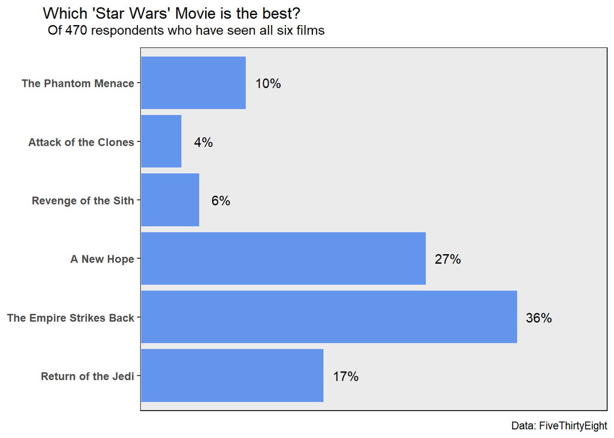

```r
secondViz = data %>%
  filter(seen == "Yes") %>%
  filter(if_all(4:9, ~str_detect(., "^1"))) %>%
  select(1:15) %>%
  mutate_at("fave3", ~replace_na(., "6")) %>%
  mutate_at(10:15, ~as.numeric(.)) %>%
  summarise(across(10:15, ~str_detect(., "^1"))) %>%
  pivot_longer(everything(), names_to = "episode", values_to = "score") %>%
  group_by(episode) %>%
  summarise(sum = sum(score)) %>%
  mutate(episode = recode(episode,
                          "fave1" = "The Phantom Menace",
                          "fave2" = "Attack of the Clones",
                          "fave3" = "Revenge of the Sith",
                          "fave4" = "A New Hope",
                          "fave5" = "The Empire Strikes Back",
                          "fave6" = "Return of the Jedi"))

ggplot(secondViz) +
  aes(x = factor(episode, level = movie_order), y = sum) +
  geom_bar(stat = "identity", fill = "cornflowerblue") +
  coord_flip(ylim = c(9.12, 200)) +
  scale_x_discrete(limits = rev) +
  scale_y_continuous() +
  labs(title = "Which 'Star Wars' Movie is the best?",
       subtitle = "Of 470 respondents who have seen all six films",
       caption = "Data: FiveThirtyEight",
       x = NULL, y = NULL) +
  theme(plot.title = element_text(hjust= -0.47),
        plot.subtitle = element_text(hjust = -0.49, vjust = 2.5),
        axis.text.x = element_blank(), axis.ticks.x = element_blank(), axis.text.y = element_text(face = "bold", size = 9),
        panel.grid = element_blank(), panel.border = element_rect(color = "black", fill = NA, size = 0.5)) +
  geom_text(data = secondViz, aes(x = episode, y = 10+sum, label = paste(formatC(100*(sum/470), digits = 0, format = "f"),"%",sep = "")))
```

[figure not shown]

```r
thirdViz = data %>%
  filter(seen == "Yes") %>%
  filter(if_all(4:9, ~str_detect(., "^1"))) %>%
  select(1:15) %>%
  mutate_at("fave3", ~replace_na(., "6")) %>%
  mutate_at(10:15, ~as.numeric(.)) %>%
  mutate(across(10:15, ~recode(.,
                              "1" = "1",
                              "2" = "1",
                              "3" = "2",
                              "4" = "2",
                              "5" = "3",
                              "6" = "3"))) %>%
  select(10:15) %>%
  pivot_longer(everything(), names_to = "episode", values_to = "score") %>%
  group_by(episode) %>%
  summarise(top = sum(score == "1"), mid = sum(score == "2"), bot = sum(score == "3")) %>%
  mutate(episode = recode(episode,
                          "fave1" = "The Phantom Menace",
                          "fave2" = "Attack of the Clones",
                          "fave3" = "Revenge of the Sith",
                          "fave4" = "A New Hope",
                          "fave5" = "The Empire Strikes Back",
                          "fave6" = "Return of the Jedi")) %>%
  pivot_longer(cols = top:bot, names_to = "third", values_to = "score") %>%
  mutate_at("third", ~factor(., levels = c("top", "mid", "bot")))

labelTrue = list(
  "top" = "Top third",
  "mid" = "Middle third",
  "bot" = "Bottom third"
)

labelThird = function(variable, value){
  return(labelTrue[value])
}

ggplot(thirdViz) +
  aes(x = factor(episode, level = movie_order), y = score, fill = third) +
  geom_bar(stat = "identity") +
  coord_flip(ylim = c(17, 400)) +
  scale_x_discrete(limits = rev) +
  scale_y_continuous() +
  labs(title = "How People Rate the 'Star Wars' Movies" ,
       subtitle =
       "How often each film was rated in the top, middle, and bottom third
       (by the 470 respondents who have seen all six films)",
       caption = "Data: FiveThirtyEight",
       x = NULL, y = NULL) +
  theme(plot.title = element_text(hjust= -5.5, face = "bold", size = 20),
        plot.subtitle = element_text(hjust = -0.8, vjust = 2.5, size = 10),
        axis.text.x = element_blank(), axis.ticks.x = element_blank(),
        axis.text.y = element_text(face = "bold", size = 8), axis.ticks.y = element_blank(),
        panel.grid = element_blank(), panel.border = element_blank(), panel.background = element_blank(),
        strip.background = element_blank(), strip.text = element_text(family = "sans", face = "bold", size = 10),
        legend.position = "none") +
  geom_text(data = thirdViz, aes(x = episode, y = 45+score,
                                 label = paste(formatC(100*(score/470), digits = 0, format = "f"),"%", sep = ""))) +
  facet_grid(cols = vars(third), margins = F, labeller = labelThird) +
  scale_fill_manual(values = c("#75ae3f","#0090d5","#fd2800"))
```

The final “serious” visualization done in the article involves a handful of characters from these six films which were rated using a format used by political polls, where respondents rate characters as “Favorable”, “Neutral”, “Unfavorable” or “Unfamiliar” based on their own opinion. FiveThirtyEight then went on to exclaim that the character **Jar Jar Binks** surprisingly had a lower favorability rating than **Emperor Palpatine**, one of the main antagonists of the series. To me, this wasn’t surprising at all considering the comedic way that Jar Jar talks and the clumsiness of the character creating a rift between what original trilogy fans consider to be the films’ relatively dark themes and Jar Jar’s comedic relief.

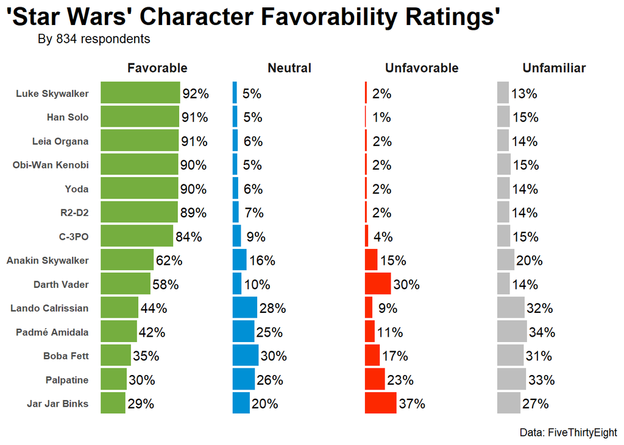

```r
character_order = c("Luke Skywalker", "Han Solo", "Leia Organa", "Obi-Wan Kenobi", "Yoda", "R2-D2", "C-3PO", "Anakin Skywalker", "Darth Vader", "Lando Calrissian", "Padmé Amidala", "Boba Fett", "Palpatine", "Jar Jar Binks")

fourthViznames = as.data.frame(starwars$name)
colnames(fourthViznames) = "name"
fourthViznames = fourthViznames %>%
  mutate("realname" = name) %>%
  mutate(across(1, str_extract, "^([\\S]+)")) %>%
  mutate(name = replace(name, 4, "vader")) %>%
  mutate(name = replace(name, 34, "jarjar")) %>%
  mutate(name = replace(name, 87, "padme")) %>%
  mutate(across(1, ~tolower(.))) %>%
  mutate(across(1, ~gsub("-", "", .)))



fourthViz = data %>%
  filter(seen == "Yes") %>%
  mutate_at(16:29, ~recode(., "Very unfavorably" = 3,
                              "Somewhat unfavorably" = 3,
                              "Neither favorably nor unfavorably (neutral)" = 2,
                              "Somewhat favorably" = 1,
                              "Very favorably" = 1,
                              "Unfamiliar (N/A)" = 0,
                              .missing = 0)) %>%
  select(16:29) %>%
  pivot_longer(everything(), names_to = "character", values_to = "score") %>%
  group_by(character) %>%
  summarise(Favorable = sum(score == "1"), Neutral = sum(score == "2"), Unfavorable = sum(score == "3"), Unfamiliar = sum(score == "0")) %>%
  left_join(fourthViznames, by = c("character" = "name"), keep = F) %>%
  pivot_longer(cols = Favorable:Unfamiliar, names_to = "favorability", values_to = "votes") %>%
  mutate(favorability = factor(favorability, levels = c("Favorable", "Neutral", "Unfavorable", "Unfamiliar")))

ggplot(fourthViz) +
  aes(x = factor(realname, levels = character_order), y = votes, fill = favorability) +
  geom_bar(stat = "identity") +
  coord_flip(ylim = c(0, 1100)) +
  scale_x_discrete(limits = rev) +
  scale_y_continuous() +
  labs(title = "'Star Wars' Character Favorability Ratings'" ,
       subtitle = "By 834 respondents",
       caption = "Data: FiveThirtyEight") +
  geom_text(data = fourthViz, aes(x = realname, y = 150+votes,
                                 label = paste(formatC(100*(votes/834), digits = 0, format = "f"),"%", sep = ""))) +
  theme(plot.title = element_text(hjust= -3.2, face = "bold", size = 20),
        plot.subtitle = element_text(hjust = -0.14, vjust = 2.5, size = 10),
        axis.text.x = element_blank(), axis.ticks.x = element_blank(), axis.title.x = element_blank(),
        axis.text.y = element_text(face = "bold", size = 8), axis.ticks.y = element_blank(), axis.title.y = element_blank(),
        panel.grid = element_blank(), panel.border = element_blank(), panel.background = element_blank(),
        strip.background = element_blank(), strip.text = element_text(family = "sans", face = "bold", size = 10),
        legend.position = "none") +
  facet_grid(cols = vars(favorability), margins = F) +
  scale_fill_manual(values = c("#75ae3f","#0090d5","#fd2800","gray"))
```

After this visualization they proceed to show one final one which has the survey respondents question to the question “Who Shot First?” in the context of the scene in which Han Solo kills a character named Greedo from ‘Star Wars Episode IV: A New Hope’. This scene in particular was extremely controversial as in the original film Han shoots and kills Greedo, however in later versions, the scene was edited to make Greedo attempt to shoot and miss and Han fires back in retaliation.

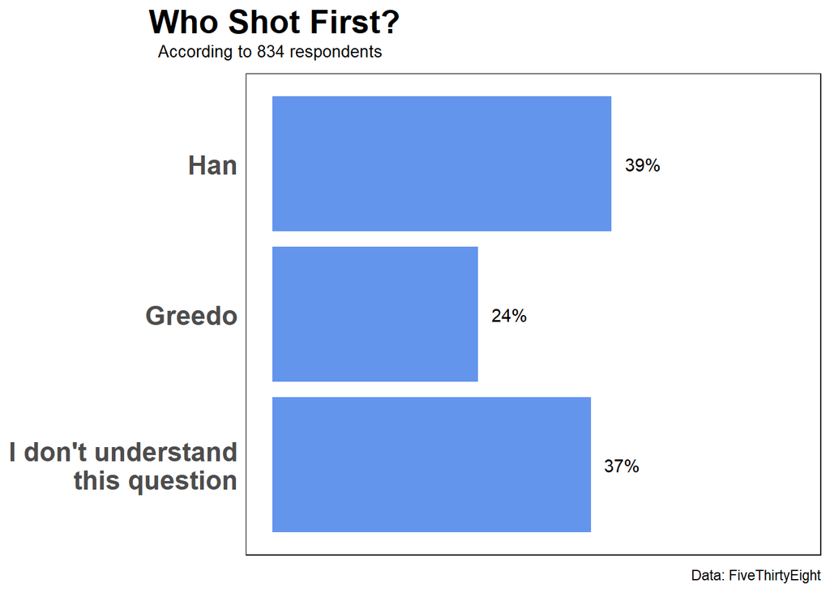

```r
fifthViz = data %>%
  filter(seen == "Yes") %>%
  select(shot) %>%
  group_by(shot) %>%
  count() %>%
  filter(shot != "NA")

ggplot(fifthViz) +
  aes(x = factor(shot, levels = c("Han", "Greedo", "I don't understand this question")), y = n) +
  geom_bar(stat = "identity", fill = "cornflowerblue") +
  scale_x_discrete(limits = rev, labels = function(x) str_wrap(str_replace_all(x, "foo" , " "),
                                                 width = 18)) + #Creating function to line break after 18 characters.
  scale_y_continuous() +
  coord_flip(ylim = c(0, 500)) +
  geom_text(data = fifthViz, aes(x = shot, y = 30+n,
                                 label = paste(formatC(100*(n/834), digits = 0, format = "f"),"%", sep = ""))) +
  theme(plot.title = element_text(hjust= -0.3, face = "bold", size = 20),
        plot.subtitle = element_text(hjust = -0.25, vjust = 2.5, size = 10),
        axis.text.x = element_blank(), axis.ticks.x = element_blank(), axis.title.x = element_blank(),
        axis.text.y = element_text(face = "bold", size = 16), axis.ticks.y = element_blank(), axis.title.y = element_blank(),
        panel.grid = element_blank(), panel.border = element_rect(color = "black", fill = NA, size = 0.5), panel.background = element_blank(),
        strip.background = element_blank(), strip.text = element_text(family = "sans", face = "bold", size = 10),
        legend.position = "none") +
  labs(title = "Who Shot First?",
       subtitle = "According to 834 respondents",
       caption = "Data: FiveThirtyEight")
```

### Discussion

Since the original trilogy was rated into the top third of the ratings much more often than the prequel trilogy. I wanted to see if the older age groups rated the original trilogy higher since they might have had a sort of nostalgic feel about the films. To attempt to answer this question I decided to color the bars by age groups.

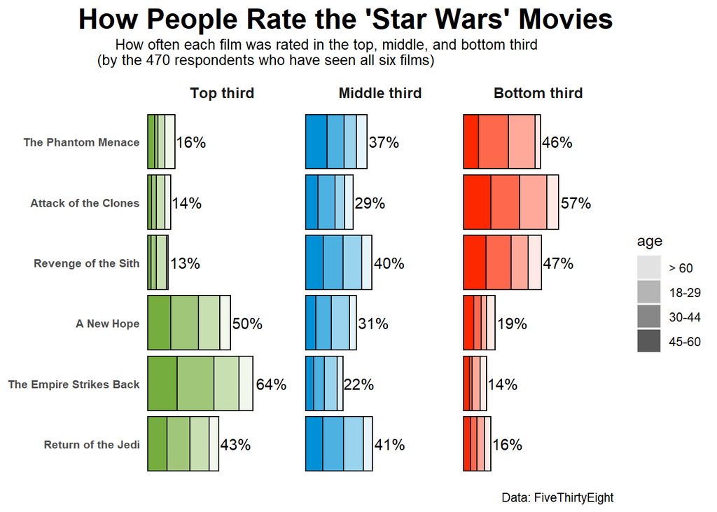

```r
discViz = data %>%
  filter(seen == "Yes") %>%
  filter(if_all(4:9, ~str_detect(., "^1"))) %>%
  select(1:15, 35) %>%
  mutate_at("fave3", ~replace_na(., "6")) %>%
  mutate_at(10:15, ~as.numeric(.)) %>%
  mutate(across(10:15, ~recode(.,
                              "1" = "1",
                              "2" = "1",
                              "3" = "2",
                              "4" = "2",
                              "5" = "3",
                              "6" = "3"))) %>%
  select(10:16) %>%
  group_by(age) %>%
  pivot_longer(1:6, names_to = "episode", values_to = "score") %>%
  group_by(episode, age) %>%
  summarise(top = sum(score == "1"), mid = sum(score == "2"), bot = sum(score == "3")) %>%
  filter(age != "NA") %>%
  mutate(episode = recode(episode,
                          "fave1" = "The Phantom Menace",
                          "fave2" = "Attack of the Clones",
                          "fave3" = "Revenge of the Sith",
                          "fave4" = "A New Hope",
                          "fave5" = "The Empire Strikes Back",
                          "fave6" = "Return of the Jedi")) %>%
  pivot_longer(cols = top:bot, names_to = "third", values_to = "score") %>%
  mutate_at("third", ~factor(., levels = c("top", "mid", "bot"))) %>%
  mutate(age = as.factor(age))

ggplot(discViz) +
  aes(x = factor(episode, level = movie_order), y = score, fill = third) +
  geom_bar(stat = "identity", aes(alpha = age, color = "value")) +
  coord_flip(ylim = c(17, 400)) +
  scale_x_discrete(limits = rev) +
  scale_y_continuous() +
  labs(title = "How People Rate the 'Star Wars' Movies" ,
       subtitle =
       "How often each film was rated in the top, middle, and bottom third
       (by the 470 respondents who have seen all six films)",
       caption = "Data: FiveThirtyEight",
       x = NULL, y = NULL) +
  theme(plot.title = element_text(hjust= 1, face = "bold", size = 20),
        plot.subtitle = element_text(hjust = -0.8, vjust = 2.5, size = 10),
        axis.text.x = element_blank(), axis.ticks.x = element_blank(),
        axis.text.y = element_text(face = "bold", size = 8), axis.ticks.y = element_blank(),
        panel.grid = element_blank(), panel.border = element_blank(), panel.background = element_blank(),
        strip.background = element_blank(), strip.text = element_text(family = "sans", face = "bold", size = 10)) +
  geom_text(data = thirdViz, aes(x = episode, y = 45+score,
                                 label = paste(formatC(100*(score/470), digits = 0, format = "f"),"%", sep = ""))) +
  facet_grid(cols = vars(third), margins = F, labeller = labelThird) +
  scale_fill_manual(values = c("#75ae3f","#0090d5","#fd2800")) +
  scale_color_manual(values = "black") +
  guides(color = F, fill = F)
```

Looking at this we can see that the age groups didn’t vote differently very dramatically. In fact it looks almost as if they voted around the same for each movie. Naturally we can’t conclude this confidently without some statistical test result backing up our conclusion. To test whether our mean scores differed among age groups we can use a Kruskal Wallis one way analysis of variance.

#### Prequel Kruskal tests

```r
kruskal.test(age ~ score, data = ep1data)
```

```
##
##  Kruskal-Wallis rank sum test
##
## data:  age by score
## Kruskal-Wallis chi-squared = 13.052, df = 2, p-value = 0.001465
```

```r
kruskal.test(age ~ score, data = ep2data)
```

```
##
##  Kruskal-Wallis rank sum test
##
## data:  age by score
## Kruskal-Wallis chi-squared = 10.147, df = 2, p-value = 0.00626
```

```r
kruskal.test(age ~ score, data = ep3data)
```

```
##
##  Kruskal-Wallis rank sum test
##
## data:  age by score
## Kruskal-Wallis chi-squared = 2.8813, df = 2, p-value = 0.2368
```

#### Original Trilogy Kruskal tests.

```r
kruskal.test(age ~ score, data = ep4data)
```

```
##
##  Kruskal-Wallis rank sum test
##
## data:  age by score
## Kruskal-Wallis chi-squared = 4.0428, df = 2, p-value = 0.1325
```

```r
kruskal.test(age ~ score, data = ep5data)
```

```
##
##  Kruskal-Wallis rank sum test
##
## data:  age by score
## Kruskal-Wallis chi-squared = 9.6165, df = 2, p-value = 0.008162
```

```r
kruskal.test(age ~ score, data = ep6data)
```

```
##
##  Kruskal-Wallis rank sum test
##
## data:  age by score
## Kruskal-Wallis chi-squared = 2.8466, df = 2, p-value = 0.2409
```

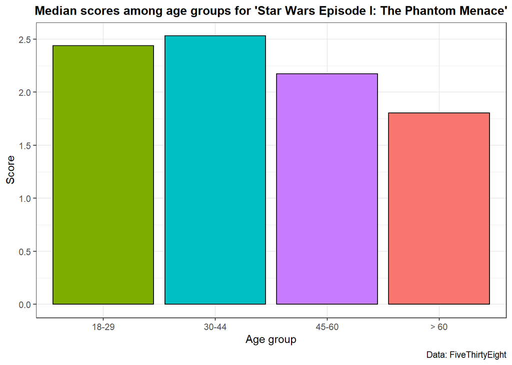

```r
ggplot(ep1data) +
  aes(x = age, y = score, fill = age) +
  stat_summary(geom = "bar", fun = "mean", color = "black") +
  scale_x_discrete(limits = c("18-29", "30-44", "45-60", "> 60"))+
  labs(x = "Age group", y = "Score", title = "Median scores among age groups for 'Star Wars Episode I: The Phantom Menace'",
       caption = "Data: FiveThirtyEight") +
  theme_bw() +
  theme(plot.title = element_text(hjust= 0.5, face = "bold", size = 12),
        legend.position = "none")
```

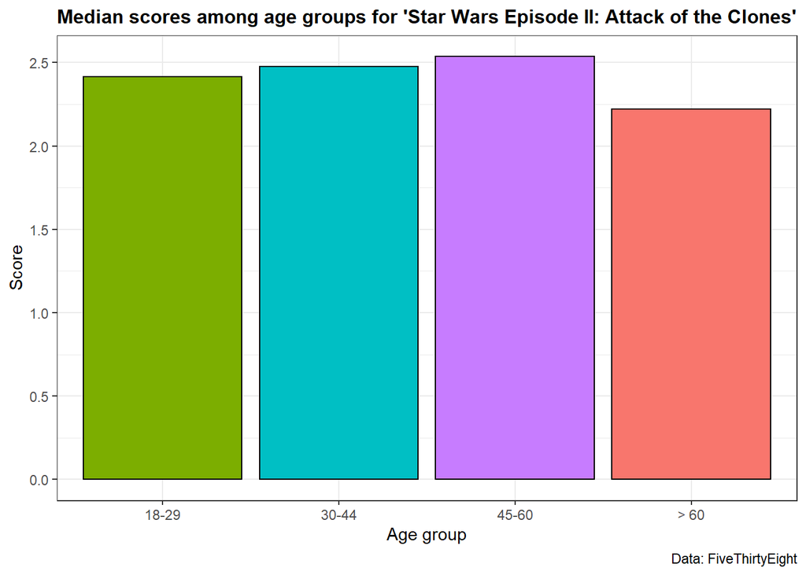

```r
ggplot(ep2data) +
  aes(x = age, y = score, fill = age) +
  stat_summary(geom = "bar", fun = "mean", color = "black") +
  scale_x_discrete(limits = c("18-29", "30-44", "45-60", "> 60")) +
  labs(x = "Age group", y = "Score", title = "Median scores among age groups for 'Star Wars Episode II: Attack of the Clones'",
       caption = "Data: FiveThirtyEight") +
  theme_bw() +
  theme(plot.title = element_text(hjust= 0.5, face = "bold", size = 12),
        legend.position = "none")
```

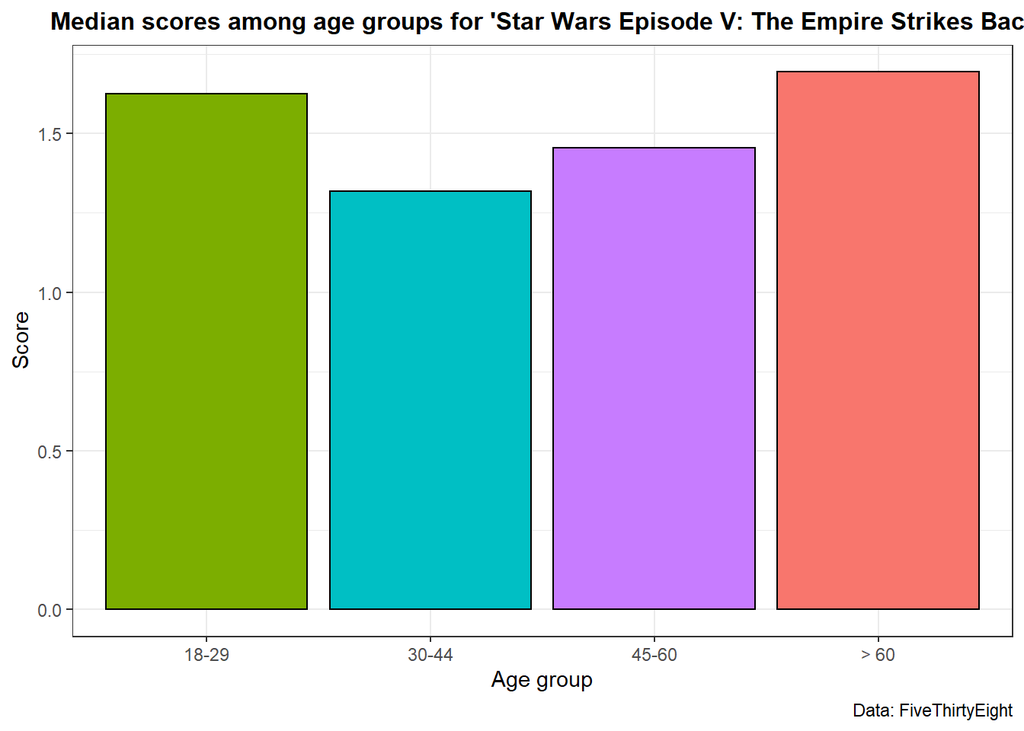

```r
ggplot(ep5data) +
  aes(x = age, y = score, fill = age) +
  stat_summary(geom = "bar", fun = "mean", color = "black") +
  scale_x_discrete(limits = c("18-29", "30-44", "45-60", "> 60")) +
  labs(x = "Age group", y = "Score", title = "Median scores among age groups for 'Star Wars Episode V: The Empire Strikes Back'",
       caption = "Data: FiveThirtyEight") +
  theme_bw() +
  theme(plot.title = element_text(hjust= 0.4, face = "bold", size = 12),
        legend.position = "none")
```

Based on this, for the first movie, the significant differences occurred between the age groups of 30-44 year olds and > 60 year olds. In the second movie, the differences occurred between the age group of 45-60 year olds and > 60 year olds. And in the fifth movie, the differences occurred between the age groups of 30-44 year olds and > 60 year olds.

One final thing I noticed about this data set was how difficult it was to work with at first due to the structuring of the original data. There was a lot of “X.1, X.2, etc.” variables that needed to be deciphered by looking at the context of the data it contained. The original data required lots of dplyr functions to get it into a workable state. I assume it was just the creator of the data set being lazy, but compared to some of the other data found in the FiveThirtyEight Github, I felt that this data set was just a little on the unorganized side. The original data set can be seen below.

```r
kbl(ogdata) %>%
  kable_styling(bootstrap_options = c("striped", "hover", "condensed", "responsive"),
                full_width = F, position = "center") %>%
  scroll_box(width = "100%", height = "465px")
```

[output not shown]

[output cut: 1157 more lines]